# 학생음주분석

```python
import numpy as np # 고성능의 수치계산을 위해 사용하는 라이브러리!
import pandas as pd # 읽어온 data를 정제하기 위한 라이브러리
import matplotlib.pyplot as plt # 시각화를 위한 라이브러리
import seaborn as sns # 시각화를 위한 라이브러리
```

```python
# 마크다운에 이미지를 넣기 위한 처리
!pip install IPython
from IPython.display import Image
%matplotlib inline
```

## 연구배경 및 목적

https://news.joins.com/article/23039632

[figure not shown]

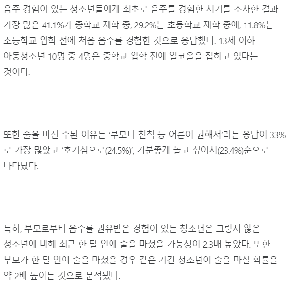

##### 청소년의 음주 경험이라는 기사를 보았을때 부모로부터 음주를 권유받은 경험이 있는 청소년이 그렇지 않은 청소년보다 한달안에 술을 마셨을 가능서잉 더 높다는 내용을 보았다.

##### 해당 내용을 가지고 부모의 영향이 아이의 음주에 영향을 미치는가를 알아보고 싶어서 진행

```python
raw_data = pd.read_csv("student_alchol.csv")
# 포르투갈 청소년의 음주 데이터
raw_data
```

|  | sex | age | address | famsize | Pstatus | Medu | Fedu | Mjob | Fjob | guardian | ... | higher | internet | romantic | famrel | freetime | goout | Dalc | Walc | health | absences |
| --- | --- | --- | --- | --- | --- | --- | --- | --- | --- | --- | --- | --- | --- | --- | --- | --- | --- | --- | --- | --- | --- |
| 0 | F | 18 | U | GT3 | A | 4 | 4 | at_home | teacher | mother | ... | yes | no | no | 4 | 3 | 4 | 1 | 1 | 3 | 4 |
| 1 | F | 17 | U | GT3 | T | 1 | 1 | at_home | other | father | ... | yes | yes | no | 5 | 3 | 3 | 1 | 1 | 3 | 2 |
| 2 | F | 15 | U | LE3 | T | 1 | 1 | at_home | other | mother | ... | yes | yes | no | 4 | 3 | 2 | 2 | 3 | 3 | 6 |
| 3 | F | 15 | U | GT3 | T | 4 | 2 | health | services | mother | ... | yes | yes | yes | 3 | 2 | 2 | 1 | 1 | 5 | 0 |
| 4 | F | 16 | U | GT3 | T | 3 | 3 | other | other | father | ... | yes | no | no | 4 | 3 | 2 | 1 | 2 | 5 | 0 |
| 5 | M | 16 | U | LE3 | T | 4 | 3 | services | other | mother | ... | yes | yes | no | 5 | 4 | 2 | 1 | 2 | 5 | 6 |
| 6 | M | 16 | U | LE3 | T | 2 | 2 | other | other | mother | ... | yes | yes | no | 4 | 4 | 4 | 1 | 1 | 3 | 0 |
| 7 | F | 17 | U | GT3 | A | 4 | 4 | other | teacher | mother | ... | yes | no | no | 4 | 1 | 4 | 1 | 1 | 1 | 2 |
| 8 | M | 15 | U | LE3 | A | 3 | 2 | services | other | mother | ... | yes | yes | no | 4 | 2 | 2 | 1 | 1 | 1 | 0 |
| 9 | M | 15 | U | GT3 | T | 3 | 4 | other | other | mother | ... | yes | yes | no | 5 | 5 | 1 | 1 | 1 | 5 | 0 |
| 10 | F | 15 | U | GT3 | T | 4 | 4 | teacher | health | mother | ... | yes | yes | no | 3 | 3 | 3 | 1 | 2 | 2 | 2 |
| 11 | F | 15 | U | GT3 | T | 2 | 1 | services | other | father | ... | yes | yes | no | 5 | 2 | 2 | 1 | 1 | 4 | 0 |
| 12 | M | 15 | U | LE3 | T | 4 | 4 | health | services | father | ... | yes | yes | no | 4 | 3 | 3 | 1 | 3 | 5 | 0 |
| 13 | M | 15 | U | GT3 | T | 4 | 3 | teacher | other | mother | ... | yes | yes | no | 5 | 4 | 3 | 1 | 2 | 3 | 0 |
| 14 | M | 15 | U | GT3 | A | 2 | 2 | other | other | other | ... | yes | yes | yes | 4 | 5 | 2 | 1 | 1 | 3 | 0 |
| 15 | F | 16 | U | GT3 | T | 4 | 4 | health | other | mother | ... | yes | yes | no | 4 | 4 | 4 | 1 | 2 | 2 | 6 |
| 16 | F | 16 | U | GT3 | T | 4 | 4 | services | services | mother | ... | yes | yes | no | 3 | 2 | 3 | 1 | 2 | 2 | 10 |
| 17 | F | 16 | U | GT3 | T | 3 | 3 | other | other | mother | ... | yes | no | no | 5 | 3 | 2 | 1 | 1 | 4 | 2 |
| 18 | M | 17 | U | GT3 | T | 3 | 2 | services | services | mother | ... | yes | yes | no | 5 | 5 | 5 | 2 | 4 | 5 | 2 |
| 19 | M | 16 | U | LE3 | T | 4 | 3 | health | other | father | ... | yes | yes | no | 3 | 1 | 3 | 1 | 3 | 5 | 6 |
| 20 | M | 15 | U | GT3 | T | 4 | 3 | teacher | other | mother | ... | yes | yes | no | 4 | 4 | 1 | 1 | 1 | 1 | 0 |
| 21 | M | 15 | U | GT3 | T | 4 | 4 | health | health | father | ... | yes | yes | no | 5 | 4 | 2 | 1 | 1 | 5 | 0 |
| 22 | M | 16 | U | LE3 | T | 4 | 2 | teacher | other | mother | ... | yes | yes | no | 4 | 5 | 1 | 1 | 3 | 5 | 0 |
| 23 | M | 16 | U | LE3 | T | 2 | 2 | other | other | mother | ... | yes | yes | no | 5 | 4 | 4 | 2 | 4 | 5 | 2 |
| 24 | F | 15 | R | GT3 | T | 2 | 4 | services | health | mother | ... | yes | yes | no | 4 | 3 | 2 | 1 | 1 | 5 | 2 |
| 25 | F | 16 | U | GT3 | T | 2 | 2 | services | services | mother | ... | yes | yes | no | 1 | 2 | 2 | 1 | 3 | 5 | 6 |
| 26 | M | 15 | U | GT3 | T | 2 | 2 | other | other | mother | ... | yes | yes | no | 4 | 2 | 2 | 1 | 2 | 5 | 8 |
| 27 | M | 15 | U | GT3 | T | 4 | 2 | health | services | mother | ... | yes | yes | no | 2 | 2 | 4 | 2 | 4 | 1 | 0 |
| 28 | M | 16 | U | LE3 | A | 3 | 4 | services | other | mother | ... | yes | yes | no | 5 | 3 | 3 | 1 | 1 | 5 | 2 |
| 29 | M | 16 | U | GT3 | T | 4 | 4 | teacher | teacher | mother | ... | yes | yes | yes | 4 | 4 | 5 | 5 | 5 | 5 | 4 |
| ... | ... | ... | ... | ... | ... | ... | ... | ... | ... | ... | ... | ... | ... | ... | ... | ... | ... | ... | ... | ... | ... |
| 1014 | M | 18 | R | GT3 | T | 1 | 3 | at_home | other | mother | ... | yes | no | no | 3 | 3 | 4 | 2 | 4 | 3 | 4 |
| 1015 | M | 18 | U | LE3 | T | 4 | 4 | teacher | services | mother | ... | yes | yes | yes | 4 | 2 | 2 | 2 | 2 | 5 | 0 |
| 1016 | F | 17 | R | GT3 | T | 1 | 1 | other | services | mother | ... | yes | yes | yes | 5 | 2 | 1 | 1 | 2 | 1 | 0 |
| 1017 | F | 18 | U | GT3 | T | 2 | 3 | at_home | services | father | ... | yes | yes | yes | 5 | 2 | 3 | 1 | 2 | 4 | 0 |
| 1018 | F | 18 | R | GT3 | T | 4 | 4 | other | teacher | father | ... | yes | yes | yes | 3 | 2 | 2 | 4 | 2 | 5 | 10 |
| 1019 | F | 19 | U | LE3 | T | 3 | 2 | services | services | other | ... | yes | no | yes | 3 | 2 | 2 | 1 | 1 | 3 | 4 |
| 1020 | M | 18 | R | LE3 | T | 1 | 2 | at_home | services | father | ... | no | yes | yes | 4 | 3 | 3 | 2 | 3 | 3 | 3 |
| 1021 | F | 17 | U | GT3 | T | 2 | 2 | other | at_home | mother | ... | yes | no | yes | 3 | 4 | 3 | 1 | 1 | 3 | 8 |
| 1022 | F | 17 | R | GT3 | T | 1 | 2 | other | other | mother | ... | yes | yes | no | 3 | 5 | 5 | 1 | 3 | 1 | 14 |
| 1023 | F | 18 | R | LE3 | T | 4 | 4 | other | other | mother | ... | yes | yes | no | 5 | 4 | 4 | 1 | 1 | 1 | 0 |
| 1024 | F | 18 | R | GT3 | T | 1 | 1 | other | other | mother | ... | yes | yes | no | 4 | 3 | 2 | 1 | 2 | 4 | 2 |
| 1025 | F | 20 | U | GT3 | T | 4 | 2 | health | other | other | ... | yes | yes | yes | 5 | 4 | 3 | 1 | 1 | 3 | 4 |
| 1026 | F | 18 | R | LE3 | T | 4 | 4 | teacher | services | mother | ... | yes | yes | no | 5 | 4 | 3 | 3 | 4 | 2 | 4 |
| 1027 | F | 18 | U | GT3 | T | 3 | 3 | other | other | mother | ... | yes | yes | yes | 4 | 1 | 3 | 1 | 2 | 1 | 0 |
| 1028 | F | 17 | R | GT3 | T | 3 | 1 | at_home | other | mother | ... | yes | yes | no | 4 | 5 | 4 | 2 | 3 | 1 | 17 |
| 1029 | M | 18 | U | GT3 | T | 4 | 4 | teacher | teacher | father | ... | yes | yes | no | 3 | 2 | 4 | 1 | 4 | 2 | 4 |
| 1030 | M | 18 | R | GT3 | T | 2 | 1 | other | other | mother | ... | yes | yes | yes | 4 | 4 | 3 | 1 | 3 | 5 | 5 |
| 1031 | M | 17 | U | GT3 | T | 2 | 3 | other | services | father | ... | yes | yes | no | 4 | 4 | 3 | 1 | 1 | 3 | 2 |
| 1032 | M | 19 | R | GT3 | T | 1 | 1 | other | services | mother | ... | yes | no | no | 4 | 3 | 2 | 1 | 3 | 5 | 0 |
| 1033 | M | 18 | R | GT3 | T | 4 | 2 | other | other | father | ... | yes | no | no | 5 | 4 | 3 | 4 | 3 | 3 | 14 |
| 1034 | F | 18 | R | GT3 | T | 2 | 2 | at_home | other | mother | ... | yes | no | no | 5 | 3 | 3 | 1 | 3 | 4 | 2 |
| 1035 | F | 18 | R | GT3 | T | 4 | 4 | teacher | at_home | mother | ... | yes | yes | yes | 4 | 4 | 3 | 2 | 2 | 5 | 7 |
| 1036 | F | 19 | R | GT3 | T | 2 | 3 | services | other | mother | ... | yes | yes | no | 5 | 4 | 2 | 1 | 2 | 5 | 0 |
| 1037 | F | 18 | U | LE3 | T | 3 | 1 | teacher | services | mother | ... | yes | yes | no | 4 | 3 | 4 | 1 | 1 | 1 | 0 |
| 1038 | F | 18 | U | GT3 | T | 1 | 1 | other | other | mother | ... | yes | no | no | 1 | 1 | 1 | 1 | 1 | 5 | 0 |
| 1039 | M | 20 | U | LE3 | A | 2 | 2 | services | services | other | ... | yes | no | no | 5 | 5 | 4 | 4 | 5 | 4 | 11 |
| 1040 | M | 17 | U | LE3 | T | 3 | 1 | services | services | mother | ... | yes | yes | no | 2 | 4 | 5 | 3 | 4 | 2 | 3 |
| 1041 | M | 21 | R | GT3 | T | 1 | 1 | other | other | other | ... | yes | no | no | 5 | 5 | 3 | 3 | 3 | 3 | 3 |
| 1042 | M | 18 | R | LE3 | T | 3 | 2 | services | other | mother | ... | yes | yes | no | 4 | 4 | 1 | 3 | 4 | 5 | 0 |
| 1043 | M | 19 | U | LE3 | T | 1 | 1 | other | at_home | father | ... | yes | yes | no | 3 | 2 | 3 | 3 | 3 | 5 | 5 |

1044 rows × 26 columns

##### sex-학생의 성별 (바이너리 : 'F'-여성 또는 'M'-남성)

##### age-학생의 나이 (숫자 : 15-22)

##### address-학생의 집 주소 유형 (바이너리 : 'U'-도시 또는 'R'-시골)

##### famsize-가족 규모 (이진 : 'LE3'-3보다 작거나 같음 또는 'GT3'-3보다 큼)

##### Pstatus-부모의 동거 상태 (바이너리 : 'T'-동거 또는 'A'-떨어져 있음)

##### Medu-어머니의 교육 (숫자 : 0-없음, 1-초등 교육 (4 학년), 2 ~ 5 ~ 9 학년, 3 ~ 중등 교육 또는 4 ~ 고등 교육)

##### Fedu-아버지의 교육 (숫자 : 0-없음, 1-초등 교육 (4 학년), 2 – 5 ~ 9 학년, 3 – 중등 교육 또는 4 – 고등 교육)

##### Mjob-어머니의 직업 (명목 : '교사', '건강'관리 관련, 공무원 '서비스'(예 : 행정 또는 경찰), '집에서'또는 '기타')

##### Fjob-아버지의 직업 (명목 : '교사', '건강'관리 관련, 공무원 '서비스'(예 : 행정 또는 경찰), '집에서'또는 '기타')

##### guardian-학생의 보호자 (명목 : '어머니', '아버지'또는 '기타')

##### traveltime-집에서 학교까지의 여행 시간 (숫자 : 1-1 시간)

##### studytime-주간 학습 시간 (숫자 : 1-10 시간)

##### failures-과거 클래스 실패 수 (숫자 : 1 <= n <= 3이면 n, 4회 이상 4)

##### famsup-가족 교육 지원 (바이너리 : 예 또는 아니요)

##### paid-코스 과목 내 추가 유료 수업 (수학 또는 포르투갈어) (이진 : 예 또는 아니오) * 한국의 과외

##### activities-과외 활동 (바이너리 : 예 또는 아니오) * 한국의 방과후 활동

##### higher-고등 교육을 받고자 함 (이진 : 예 또는 아니요)

##### internet-집에서 인터넷 액세스 (이진 : 예 또는 아니요)

##### romantic-낭만적 인 관계 (이진 : 예 또는 아니요) * 연애활동

##### famrel-가족 관계의 질 (숫자 : 1-매우 나쁨에서 5-우수)

##### freetime-방과 후 자유 시간 (숫자 : 1-매우 낮음에서 5-매우 높음)

##### goout-친구들과 외출 (숫자 : 1-매우 낮음에서 5-매우 높음)

##### Dalc-근무일 알코올 소비량 (숫자 : 1-매우 낮음에서 5-매우 높음) * 평일의 알코올 소비량

##### Walc-주말 알코올 소비 (숫자 : 1-매우 낮음에서 5-매우 높음)

##### health-현재 건강 상태 (숫자 : 1-매우 나쁨에서 5-매우 좋음)

##### 결석-결석 횟수 (숫자 : 0 ~ 93)

```python
raw_data.info()
# 총 1044개의 데이터가 있고 null값은 없다.
# 각각의 컬럼은 int 또는 object로 이루어져 있다.
# 결측기 확인(없음)
```

```
<class 'pandas.core.frame.DataFrame'>
RangeIndex: 1044 entries, 0 to 1043
Data columns (total 26 columns):
sex           1044 non-null object
age           1044 non-null int64
address       1044 non-null object
famsize       1044 non-null object
Pstatus       1044 non-null object
Medu          1044 non-null int64
Fedu          1044 non-null int64
Mjob          1044 non-null object
Fjob          1044 non-null object
guardian      1044 non-null object
traveltime    1044 non-null int64
studytime     1044 non-null int64
failures      1044 non-null int64
famsup        1044 non-null object
paid          1044 non-null object
activities    1044 non-null object
higher        1044 non-null object
internet      1044 non-null object
romantic      1044 non-null object
famrel        1044 non-null int64
freetime      1044 non-null int64
goout         1044 non-null int64
Dalc          1044 non-null int64
Walc          1044 non-null int64
health        1044 non-null int64
absences      1044 non-null int64
dtypes: int64(13), object(13)
memory usage: 212.1+ KB
```

```python
raw_data.describe()
# int 타입의 컬럼의 다양한 숫자 데이터를 출력
```

|  | age | Medu | Fedu | traveltime | studytime | failures | famrel | freetime | goout | Dalc | Walc | health | absences |
| --- | --- | --- | --- | --- | --- | --- | --- | --- | --- | --- | --- | --- | --- |
| count | 1044.000000 | 1044.000000 | 1044.000000 | 1044.000000 | 1044.000000 | 1044.000000 | 1044.000000 | 1044.000000 | 1044.000000 | 1044.000000 | 1044.000000 | 1044.000000 | 1044.000000 |
| mean | 16.726054 | 2.603448 | 2.387931 | 1.522989 | 1.970307 | 0.264368 | 3.935824 | 3.201149 | 3.156130 | 1.494253 | 2.284483 | 3.543103 | 4.434866 |
| std | 1.239975 | 1.124907 | 1.099938 | 0.731727 | 0.834353 | 0.656142 | 0.933401 | 1.031507 | 1.152575 | 0.911714 | 1.285105 | 1.424703 | 6.210017 |
| min | 15.000000 | 0.000000 | 0.000000 | 1.000000 | 1.000000 | 0.000000 | 1.000000 | 1.000000 | 1.000000 | 1.000000 | 1.000000 | 1.000000 | 0.000000 |
| 25% | 16.000000 | 2.000000 | 1.000000 | 1.000000 | 1.000000 | 0.000000 | 4.000000 | 3.000000 | 2.000000 | 1.000000 | 1.000000 | 3.000000 | 0.000000 |
| 50% | 17.000000 | 3.000000 | 2.000000 | 1.000000 | 2.000000 | 0.000000 | 4.000000 | 3.000000 | 3.000000 | 1.000000 | 2.000000 | 4.000000 | 2.000000 |
| 75% | 18.000000 | 4.000000 | 3.000000 | 2.000000 | 2.000000 | 0.000000 | 5.000000 | 4.000000 | 4.000000 | 2.000000 | 3.000000 | 5.000000 | 6.000000 |
| max | 22.000000 | 4.000000 | 4.000000 | 4.000000 | 4.000000 | 3.000000 | 5.000000 | 5.000000 | 5.000000 | 5.000000 | 5.000000 | 5.000000 | 75.000000 |

## 인사이트

##### 평균나이는 16.7세 / 부모의 교육 수준은 25%부터 아빠의 교육수준이 엄마보다 1단계 낮다.

##### 통학시간은 평균 1시간 30분 / 주간 공부시간은 평균 약 20시간

##### 가족관계는 평균적으로 우수함 / 자유시간과 외출횟수는 평균 3으로 보통의 정도를 보임

##### 학교가는 주중에는 술을 잘 먹지 않음 / 주말에는 술을 약간은 먹음 / 대체로 건강한정도 / 결석은 4회가 평균

```python
raw_data.head()
# 상위 5개의 row만 노출
```

|  | sex | age | address | famsize | Pstatus | Medu | Fedu | Mjob | Fjob | guardian | ... | higher | internet | romantic | famrel | freetime | goout | Dalc | Walc | health | absences |
| --- | --- | --- | --- | --- | --- | --- | --- | --- | --- | --- | --- | --- | --- | --- | --- | --- | --- | --- | --- | --- | --- |
| 0 | F | 18 | U | GT3 | A | 4 | 4 | at_home | teacher | mother | ... | yes | no | no | 4 | 3 | 4 | 1 | 1 | 3 | 4 |
| 1 | F | 17 | U | GT3 | T | 1 | 1 | at_home | other | father | ... | yes | yes | no | 5 | 3 | 3 | 1 | 1 | 3 | 2 |
| 2 | F | 15 | U | LE3 | T | 1 | 1 | at_home | other | mother | ... | yes | yes | no | 4 | 3 | 2 | 2 | 3 | 3 | 6 |
| 3 | F | 15 | U | GT3 | T | 4 | 2 | health | services | mother | ... | yes | yes | yes | 3 | 2 | 2 | 1 | 1 | 5 | 0 |
| 4 | F | 16 | U | GT3 | T | 3 | 3 | other | other | father | ... | yes | no | no | 4 | 3 | 2 | 1 | 2 | 5 | 0 |

5 rows × 26 columns

```python
raw_data.columns
#모든 컬럼명을 확인
```

```
Index(['sex', 'age', 'address', 'famsize', 'Pstatus', 'Medu', 'Fedu', 'Mjob',
       'Fjob', 'guardian', 'traveltime', 'studytime', 'failures', 'famsup',
       'paid', 'activities', 'higher', 'internet', 'romantic', 'famrel',
       'freetime', 'goout', 'Dalc', 'Walc', 'health', 'absences'],
      dtype='object')
```

```python
type(raw_data.columns)
# 컴럼의 모임은 인덱스 타입이다.
```

```
pandas.core.indexes.base.Index
```

```python
len(raw_data.columns)
# 총 컬럼의 갯수는 26개이다.
```

```
26
```

```python
raw_data.corr()
# 숫자 데이터를 가진 값들의 상관관계도
# corr함수는 숫자형을 가진 데이터들의 상관관계도를 보여준다.
```

|  | age | Medu | Fedu | traveltime | studytime | failures | famrel | freetime | goout | Dalc | Walc | health | absences |
| --- | --- | --- | --- | --- | --- | --- | --- | --- | --- | --- | --- | --- | --- |
| age | 1.000000 | -0.130196 | -0.138521 | 0.049216 | -0.007870 | 0.282364 | 0.007162 | 0.002645 | 0.118510 | 0.133453 | 0.098291 | -0.029129 | 0.153196 |
| Medu | -0.130196 | 1.000000 | 0.642063 | -0.238181 | 0.090616 | -0.187769 | 0.015004 | 0.001054 | 0.025614 | 0.001515 | -0.029331 | -0.013254 | 0.059708 |
| Fedu | -0.138521 | 0.642063 | 1.000000 | -0.196328 | 0.033458 | -0.191390 | 0.013066 | 0.002142 | 0.030075 | -0.000165 | 0.019524 | 0.034288 | 0.040829 |
| traveltime | 0.049216 | -0.238181 | -0.196328 | 1.000000 | -0.081328 | 0.087177 | -0.012578 | -0.007403 | 0.049740 | 0.109423 | 0.084292 | -0.029002 | -0.022669 |
| studytime | -0.007870 | 0.090616 | 0.033458 | -0.081328 | 1.000000 | -0.152024 | 0.012324 | -0.094429 | -0.072941 | -0.159665 | -0.229073 | -0.063044 | -0.075594 |
| failures | 0.282364 | -0.187769 | -0.191390 | 0.087177 | -0.152024 | 1.000000 | -0.053676 | 0.102679 | 0.074683 | 0.116336 | 0.107432 | 0.048311 | 0.099998 |
| famrel | 0.007162 | 0.015004 | 0.013066 | -0.012578 | 0.012324 | -0.053676 | 1.000000 | 0.136901 | 0.080619 | -0.076483 | -0.100663 | 0.104101 | -0.062171 |
| freetime | 0.002645 | 0.001054 | 0.002142 | -0.007403 | -0.094429 | 0.102679 | 0.136901 | 1.000000 | 0.323556 | 0.144979 | 0.130377 | 0.081517 | -0.032079 |
| goout | 0.118510 | 0.025614 | 0.030075 | 0.049740 | -0.072941 | 0.074683 | 0.080619 | 0.323556 | 1.000000 | 0.253135 | 0.399794 | -0.013736 | 0.056142 |
| Dalc | 0.133453 | 0.001515 | -0.000165 | 0.109423 | -0.159665 | 0.116336 | -0.076483 | 0.144979 | 0.253135 | 1.000000 | 0.627814 | 0.065515 | 0.132867 |
| Walc | 0.098291 | -0.029331 | 0.019524 | 0.084292 | -0.229073 | 0.107432 | -0.100663 | 0.130377 | 0.399794 | 0.627814 | 1.000000 | 0.106669 | 0.139703 |
| health | -0.029129 | -0.013254 | 0.034288 | -0.029002 | -0.063044 | 0.048311 | 0.104101 | 0.081517 | -0.013736 | 0.065515 | 0.106669 | 1.000000 | -0.027479 |
| absences | 0.153196 | 0.059708 | 0.040829 | -0.022669 | -0.075594 | 0.099998 | -0.062171 | -0.032079 | 0.056142 | 0.132867 | 0.139703 | -0.027479 | 1.000000 |

## 인사이트(상관관계 25% 이상 조건)

##### 엄마의 교육수준과 아빠의 교육수준은 양의 상관관계를 가진다.

##### 친구들과 나가는 횟수는 방과 후 자유시간과 주중 주말 알코올 소비량과 조금은 상관은 있다.

##### 주중과 주말의 음주 소비량은 서로 상관이 어느정도 있다.

##### 나이와 클래스 실패는 조금은 상관이 있다.

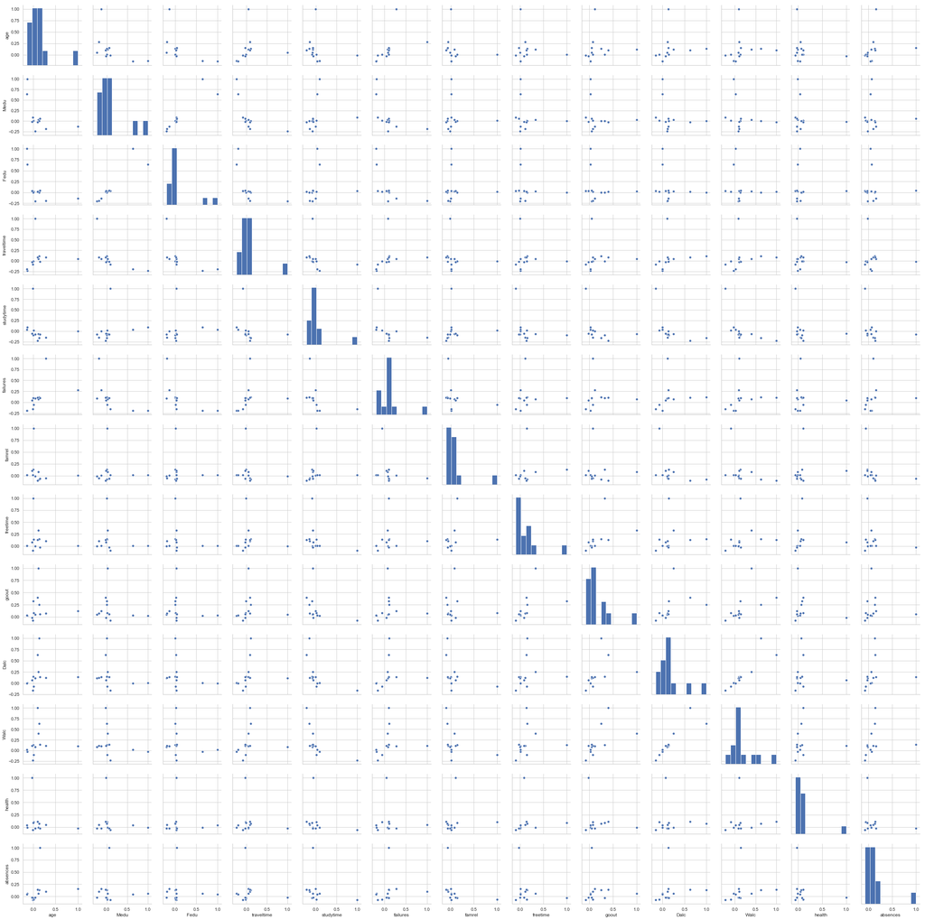

```python
# 시각화 라이브러리를 이용한 피처간의 scatter plot을 출력합니다.
sns.set(style='whitegrid', context='notebook')
sns.pairplot(raw_data.corr(), height=2.5)
plt.show()
# 페어플롯 그래프가 선형으로 이어져 잇는 경우가 상관관계가 있고 흩어져있을수록 상관관계가 아니다.
```

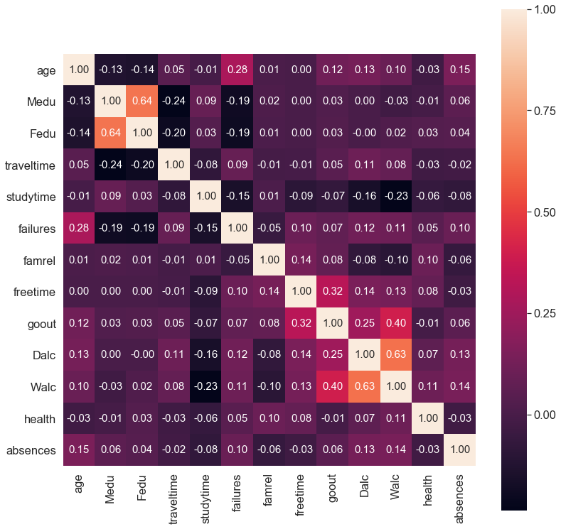

```python
cols_view = ['age','Medu', 'Fedu', 'traveltime', 'studytime', 'failures',
       'famrel', 'freetime', 'goout', 'Dalc', 'Walc', 'health', 'absences']
# heatmap 그래프 출력을 위한 컬럼을 지정
plt.figure(figsize=(13, 13)) # 정사각형 형태
sns.set(font_scale=1.5) # 글씨 크기
hm = sns.heatmap(raw_data.corr().values, # 어떤 데이터를 사용할 것인지. raw_data의 상관관계 의 값을 사용
            cbar=True, # 오른쪽 상관관계 바
            annot=True, # 각 상관관계 박스 위 글자
            square=True, # 정사각형
            fmt='.2f', # 소주점 2번째까지(포멧팅)
            annot_kws={'size': 15}, # 상관관계 박스 위글씨크기
            yticklabels=cols_view,# x축
            xticklabels=cols_view) # y축

plt.show()
```

## 기술적 통계

```python
raw_data["sex"].value_counts()
# data의 남성과 여성의 총 갯수
# 여자는 591, 남성은 453
```

```
F    591
M    453
Name: sex, dtype: int64
```

```python
f_Dalc = raw_data[raw_data["sex"] == "F"]["Dalc"].mean()
f_Dalc
# 여자 학생의 주중 알콜 소비량 평균
```

```
1.2741116751269035
```

```python
f_Walc = raw_data[raw_data["sex"] == "F"]["Walc"].mean()
f_Walc
# 여자 학생의 주말 알콜 소비량 평균
```

```
1.9441624365482233
```